# Repetitive negative thinking following exposure to a natural stressor prospectively predicts altered stress reactivity and decision making in the laboratory

#### Caitlin A. Stamatis, Nikki Puccetti, Caroline Charpentier, Aaron S. Heller, & Kiara R. Timpano

This document contains the code for analyses conducted for a manuscript in submission.

### Data cleaning and set-up

**Packages Used:** stargazer, sjPlot, sjmisc, ggplot2, lmerTest, lme4, reshape2, tidyr, doBy, psych, dplyr, nlme, summarytools, plyr, knitr, pander, DT, shiny

### View Data

|  | ID | na0 | na1 | na2 | Gender | CurrentMed_notBC_t3 | CurrentMed_BC_t3 | Smoker_0no_1yes_2yestoday_t3 | TodayCaff_NumCups_t3 | CurrentMenstr_t3 | cort0 | cort1 | cort2 | RNT_1 | mu_BL_log | lambda_BL_log | rho_BL_log | mu_ANT_log | lambda_ANT_log | rho_ANT_log | mu_REC_log | lambda_REC_log | rho_REC_log | HurricaneImpairment |
| --- | --- | --- | --- | --- | --- | --- | --- | --- | --- | --- | --- | --- | --- | --- | --- | --- | --- | --- | --- | --- | --- | --- | --- | --- |
| 1 | 5000 |  |  |  | 0 |  |  |  |  |  |  |  |  | 53 |  |  |  |  |  |  |  |  |  | 0 |
| 2 | 5001 | 2 | 16 | 2 | 0 | 0 | 0 | 0 | 0 | 0 | 2.19 | 3.75 | 2.83 | 40 | 0.761429281 | 1.100268927 | 0.767201893 | 0.775266691 | 1.075031888 | 0.76054987 | 0.495103723 | 1.17002796 | 0.839114378 | 0 |
| 3 | 5002 | 7 | 19 | 9 | 0 | 1 | 0 | 0 | 0 | 0 | 15.81 | 11.56 | 7.78 | 41 | 1.428835512 | 1.287352473 | 0.339738174 | 1.437766666 | 1.247192201 | 0.351901503 | 0.556022284 | 1.766374351 | 0.496016033 | 0 |
| 4 | 5003 | 19 | 24 | 11 | 0 | 0 | 0 | 0 | 2 | 0 | 17.11 | 19.81 | 13.28 | 40 | 0.374800091 | 1.368033352 | 0.730959665 | 0.284952125 | 1.306898894 | 0.738693444 | 0.148920798 | 2.249514692 | 0.770654242 | 0 |
| 5 | 5004 | 2 | 2 | 2 | 0 | 1 | 0 | 0 | 0 | 0 | 8.56 | 8.58 | 6.14 | 30 | 0.540027127 | 0.026362494 | 0.517190594 | 1.109552807 | 0.001591939 | 0.323645732 | 0.556070625 | 0.026636502 | 0.491990559 | 0 |
| 6 | 5005 | 16 | 25 | 2 | 1 | 0 | 0 | 0 | 3 |  | 6.08 | 10.03 | 8.89 | 26 | 0.778335774 | 1.970241444 | 0.609226434 | 0.311986426 | 2.366173706 | 0.642445819 | 0.413881451 | 2.159323528 | 0.64415096 | 0 |
| 7 | 5006 |  |  |  | 0 |  |  |  |  |  |  |  |  | 13 |  |  |  |  |  |  |  |  |  | 0 |
| 8 | 5007 | 12 | 14 | 11 | 1 | 0 | 0 | 0 | 0 |  | 3.69 | 7.75 | 9.22 | 42 | 1.087980172 | 1.05648817 | 0.563574875 | 0.600804369 | 1.270906664 | 0.695270146 | 1.064060325 | 1.117976196 | 0.577804013 | 0 |
| 9 | 5008 | 19 | 19 | 15 | 0 | 0 | 1 | 0 | 0 | 0 | 12.28 | 13.69 | 7.31 | 35 | 0.845633743 | 1.404612408 | 0.40987243 | 1.318120054 | 1.283182906 | 0.362359746 | 1.190938782 | 0.959261805 | 0.074294248 | 2 |
| 10 | 5009 | 2 | 13 | 2 | 0 | 0 | 0 | 0 | 0 | 0 | 9.94 | 14.17 | 6.25 | 37 |  |  |  |  |  |  |  |  |  | 0 |

[output cut: 80 more lines]

### Description of Variables

#### Demographic Variables

- ID: subject ID
- Gender_1: gender (0 = male; 1 = female)
- Age_1: age
- CurrentMed_notBC_t3: current medications, excluding oral contraceptive
- CurrentMed_BC_t3: current oral contraceptive
- Smoker_0no_1yes_2yestoday_t3: smoking status (0 = no; 1 = yes; 2 = yes and smoked today)
- TodayCaff_NumCups_t3: number of caffeinated beverages today
- CurrentMenstr_t3: current menstruation (1 = yes)
- HurricaneImpairment: continued impairment in day-to-day functioning after Hurricane Irma related to stress of hurricane experience

#### Self-Reported RNT

- RNT_1: repetitive negative thinking on the Perseverative Thinking Questionnaire at Time 1

#### Gambling Task

- muBL: choice consistency during baseline block
- lambdaBL: loss aversion during baseline block
- rhoBL: risk seeking during baseline block
- muANT: choice consistency during stress anticipation block
- lambdaANT: loss aversion during stress anticipation block
- rhoANT: risk seeking during stress anticipation block
- muREC: choice consistency during stress recovery block
- lambdaREC: loss aversion during stress recovery block
- rhoREC: risk seeking during stress recovery block

#### Cortisol and Momentary Negative Affect

- cort0-cort2: cortisol measures over course of session (nmol/L)
- na0-na2: negative affect measures over course of session (PANAS)

### Descriptive Statistics & Basic Data Visualization

|  | na0 | na1 | na2 | cort0 | cort1 | cort2 | RNT_1 | mu_BL_log | lambda_BL_log | rho_BL_log | mu_ANT_log | lambda_ANT_log | rho_ANT_log | mu_REC_log | lambda_REC_log | rho_REC_log | HurricaneImpairment |
| --- | --- | --- | --- | --- | --- | --- | --- | --- | --- | --- | --- | --- | --- | --- | --- | --- | --- |
| Mean | 6.5 | 11.0793650793651 | 4.96875 | 7.94444444444444 | 8.86920634920635 | 6.55 | 25.6 | 0.869190618017857 | 1.40039162808929 | 0.529084184589286 | 0.914462031678571 | 1.46954079801786 | 0.485013967089286 | 1.03060712055357 | 1.47659917367857 | 0.4622957455 | 1.42222222222222 |
| Std.Dev | 5.8851440623761 | 7.12628389632485 | 4.04329250558431 | 4.53963362802578 | 4.4320632716411 | 3.38184978029893 | 13.217115223507 | 0.64104335860611 | 0.628212472264331 | 0.281084420629215 | 0.544918175829108 | 0.748471576874298 | 0.229600631204685 | 0.685157884994884 | 0.835225310756918 | 0.275148468471116 | 2.09856975253199 |
| Min | 2 | 2 | 2 | 1.42 | 2.53 | 2.67 | 2 | 0.000807004 | 0.026362494 | 0.07501475 | 0.110542545 | 0.001591939 | 0.04210037 | 0.016582273 | 0.026636502 | 0.024304391 | 0 |
| Q1 | 2 | 5 | 2 | 4.61 | 5.5 | 3.795 | 17 | 0.42087078 | 1.0535146815 | 0.3647464775 | 0.4959878355 | 1.034557779 | 0.331321234 | 0.5511282365 | 0.9985017935 | 0.29969956 | 0 |
| Median | 4 | 9 | 3.5 | 7.22 | 8.19 | 6.125 | 24 | 0.7328983535 | 1.2537847255 | 0.531260709 | 0.759969237 | 1.2635454905 | 0.4846998685 | 0.968611253 | 1.2223385565 | 0.468637082 | 0 |
| Q3 | 9 | 15 | 6 | 11.61 | 11.08 | 7.75 | 36 | 1.1463067665 | 1.6676755555 | 0.672489692 | 1.302635169 | 1.833518712 | 0.645126658 | 1.4681886965 | 1.921022276 | 0.64183683 | 3 |
| Max | 27 | 30 | 20 | 26.72 | 24.31 | 19.28 | 60 | 3.23779851 | 3.870254191 | 1.837905047 | 2.264298967 | 3.811921274 | 1.020129335 | 3.519603504 | 4.522204563 | 1.467633946 | 8 |
| MAD | 2.9652 | 5.9304 | 2.2239 | 4.240236 | 3.988194 | 3.232068 | 12.6021 | 0.5917739055606 | 0.3712391229708 | 0.222903253881 | 0.5512565039268 | 0.5299981622838 | 0.2307055757454 | 0.6598550080143 | 0.4339311501126 | 0.2567859463848 | 0 |
| IQR | 7 | 10 | 4 | 6.86 | 5.375 | 3.9325 | 18.75 | 0.69947112225 | 0.6046138425 | 0.29847682825 | 0.79775697425 | 0.7886914105 | 0.312418518 | 0.9144635195 | 0.90948524225 | 0.333927052 | 3 |
| CV | 0.905406778827092 | 0.643203274310123 | 0.813744403639611 | 0.571422414716532 | 0.499713626804691 | 0.516312943557089 | 0.516293563418242 | 0.737517577062642 | 0.448597706286972 | 0.531265966393257 | 0.595889339253227 | 0.509323441638266 | 0.4733897305733 | 0.664809966213764 | 0.565641187971254 | 0.595178456971363 | 1.47555685724906 |

[output cut: 5 more lines]

|  | Variable | Category | Count in Category | Percent |
| --- | --- | --- | --- | --- |
| 1 | Gender | 0 | 66 | 73.3333333333333% |
| 2 | Gender | 1 | 24 | 26.6666666666667% |
| 3 | CurrentMed_notBC_t3 | 0 | 41 | 65.0793650793651% |
| 4 | CurrentMed_notBC_t3 | 1 | 22 | 34.9206349206349% |
| 5 | CurrentMed_BC_t3 | 0 | 50 | 78.125% |
| 6 | CurrentMed_BC_t3 | 1 | 14 | 21.875% |
| 7 | Smoker_0no_1yes_2yestoday_t3 | 0 | 58 | 90.625% |
| 8 | Smoker_0no_1yes_2yestoday_t3 | 1 | 4 | 6.25% |
| 9 | Smoker_0no_1yes_2yestoday_t3 | 2 | 2 | 3.125% |
| 10 | TodayCaff_NumCups_t3 | 0 | 43 | 67.1875% |

[output cut: 5 more lines]

### Cortisol Visualization

```r
cortvalues <- NA
cortvalues[1] <- mean(df$cort0, na.rm=T)
cortvalues[2] <- mean(df$cort1, na.rm=T)
cortvalues[3] <- mean(df$cort2, na.rm=T)

sevalues <- NA
a <- summarySE(df, measurevar="cort0", na.rm=T)
sevalues[1] <- a$se
a2 <- summarySE(df, measurevar="cort1", na.rm=T)
sevalues[2] <- a2$se
a3 <- summarySE(df, measurevar="cort2", na.rm=T)
sevalues[3] <- a3$se

Cortvalues <- NA
Cortvalues <- cbind(as.data.frame(cortvalues),as.data.frame(sevalues))

Cortvalues$Time <- c(0,1,2)
```

```r
p<- ggplot(Cortvalues, aes(x=Time, y=cortvalues)) +
  geom_line() +
  geom_point()+
  geom_errorbar(aes(ymin=cortvalues-sevalues, ymax=cortvalues+sevalues), width=.2,
                 position=position_dodge(0.05))
```

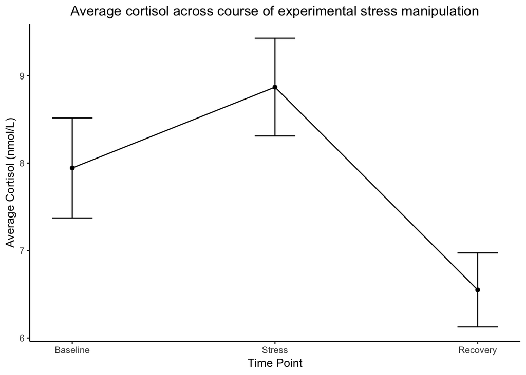

```r
# Finished line plot
p+labs(title="Average cortisol across course of experimental stress manipulation", x="Time Point", y = "Average Cortisol (nmol/L)")+ theme_classic() + scale_x_continuous(breaks=c(0,1,2), labels=c("Baseline","Stress","Recovery")) + theme(plot.title = element_text(hjust = 0.5))
```

The plot clearly indicates an average increase in cortisol during the stress induction, and a decrease in cortisol as individuals recovered from the stressor.

### Negative Affect Visualization

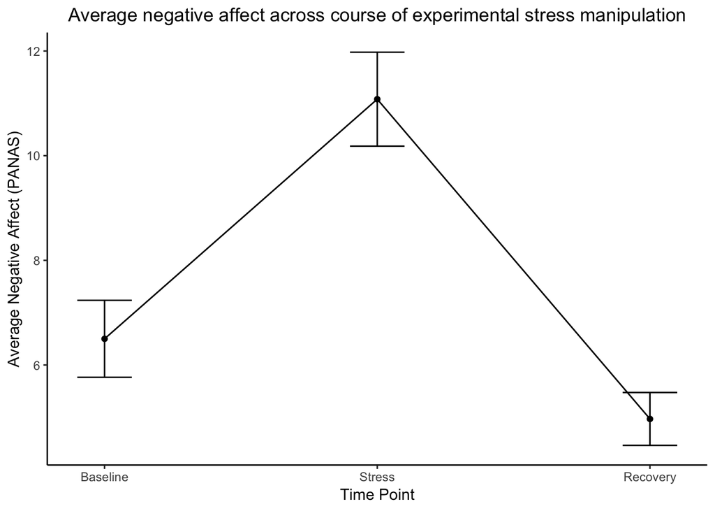

### Gambling Task Parameter Visualization

#### Rho

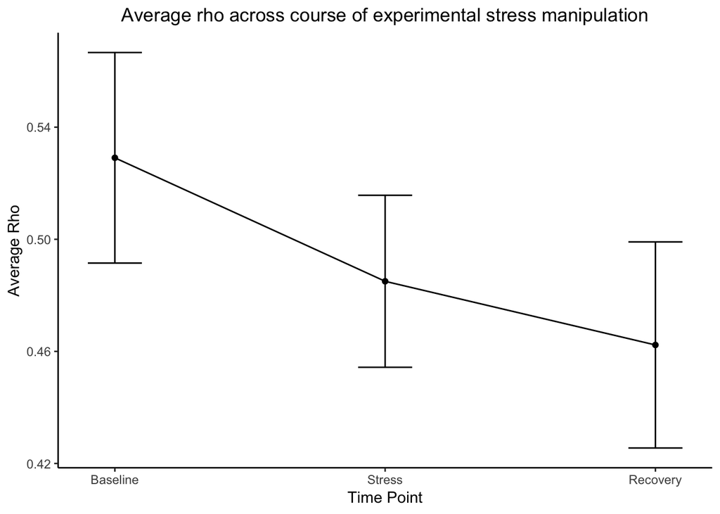

#### Lambda

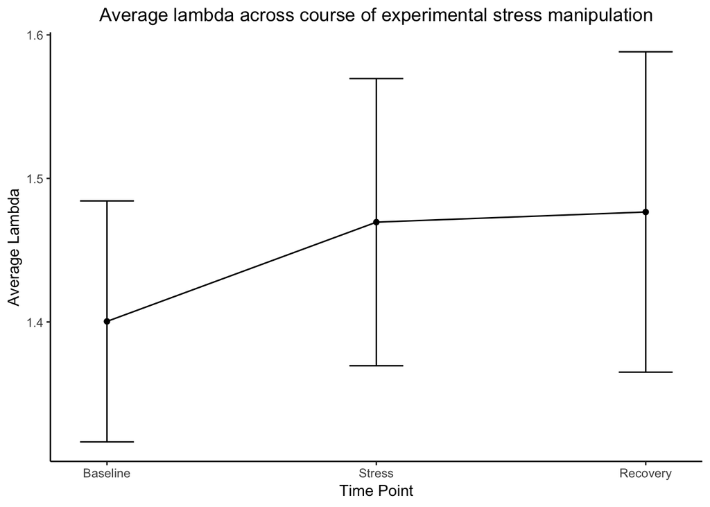

#### Mu

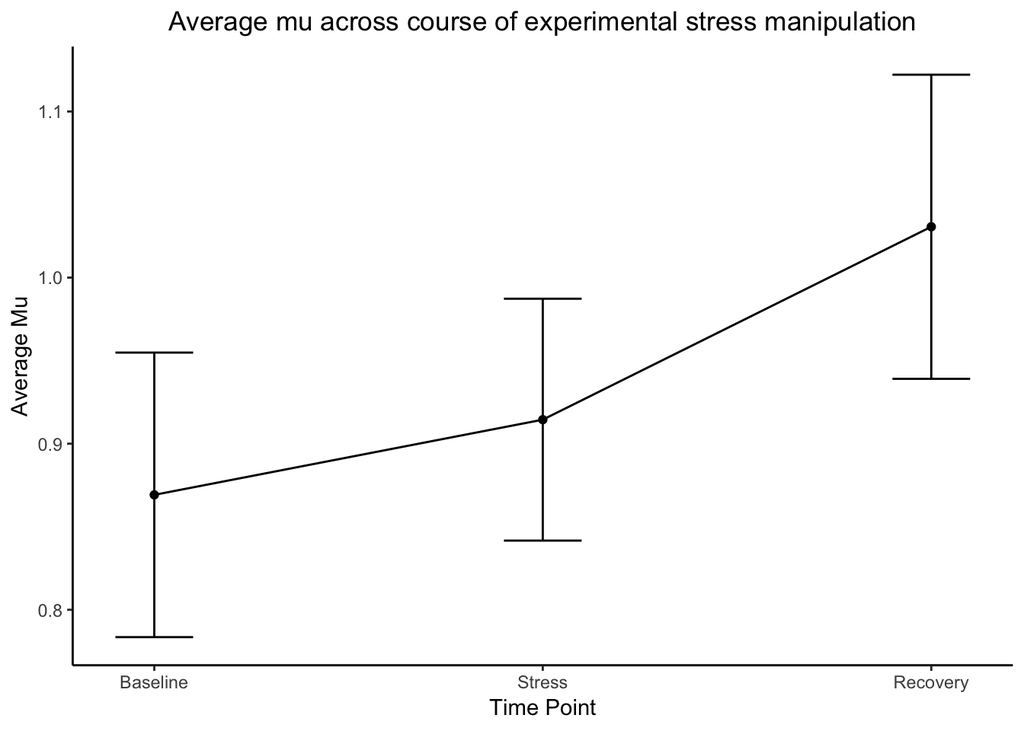

### Preliminary Analyses

```r
t.test(df$cort1, df$cort0, paired=T)
```

```
##
##  Paired t-test
##
## data:  df$cort1 and df$cort0
## t = 2.719, df = 62, p-value = 0.008483
## alternative hypothesis: true difference in means is not equal to 0
## 95 percent confidence interval:
##  0.2448777 1.6046461
## sample estimates:
## mean of the differences
##               0.9247619
```

```r
t.test(df$cort2, df$cort0, paired=T)
```

```
##
##  Paired t-test
##
## data:  df$cort2 and df$cort0
## t = -3.5126, df = 62, p-value = 0.0008341
## alternative hypothesis: true difference in means is not equal to 0
## 95 percent confidence interval:
##  -2.3209934 -0.6374193
## sample estimates:
## mean of the differences
##               -1.479206
```

```r
t.test(df$cort2, df$cort1, paired=T)
```

```
##
##  Paired t-test
##
## data:  df$cort2 and df$cort1
## t = -8.6171, df = 62, p-value = 0.000000000003386
## alternative hypothesis: true difference in means is not equal to 0
## 95 percent confidence interval:
##  -2.961636 -1.846300
## sample estimates:
## mean of the differences
##               -2.403968
```

```r
t.test(df$na1, df$na0, paired=T)
```

```
##
##  Paired t-test
##
## data:  df$na1 and df$na0
## t = 8.3599, df = 62, p-value = 0.000000000009414
## alternative hypothesis: true difference in means is not equal to 0
## 95 percent confidence interval:
##  3.430030 5.585843
## sample estimates:
## mean of the differences
##                4.507937
```

```r
t.test(df$na2, df$na0, paired=T)
```

```
##
##  Paired t-test
##
## data:  df$na2 and df$na0
## t = -3.5411, df = 63, p-value = 0.0007558
## alternative hypothesis: true difference in means is not equal to 0
## 95 percent confidence interval:
##  -2.3953757 -0.6671243
## sample estimates:
## mean of the differences
##                -1.53125
```

```r
t.test(df$na2, df$na1, paired=T)
```

```
##
##  Paired t-test
##
## data:  df$na2 and df$na1
## t = -9.645, df = 62, p-value = 0.00000000000005917
## alternative hypothesis: true difference in means is not equal to 0
## 95 percent confidence interval:
##  -7.320183 -4.806801
## sample estimates:
## mean of the differences
##               -6.063492
```

```r
t.test(df$lambda_ANT_log, df$lambda_BL_log, paired=T)
```

```
##
##  Paired t-test
##
## data:  df$lambda_ANT_log and df$lambda_BL_log
## t = 1.1049, df = 55, p-value = 0.274
## alternative hypothesis: true difference in means is not equal to 0
## 95 percent confidence interval:
##  -0.05627334  0.19457168
## sample estimates:
## mean of the differences
##              0.06914917
```

```r
t.test(df$lambda_REC_log, df$lambda_BL_log, paired=T)
```

```
##
##  Paired t-test
##
## data:  df$lambda_REC_log and df$lambda_BL_log
## t = 1.2722, df = 55, p-value = 0.2087
## alternative hypothesis: true difference in means is not equal to 0
## 95 percent confidence interval:
##  -0.04383823  0.19625332
## sample estimates:
## mean of the differences
##              0.07620755
```

```r
t.test(df$lambda_REC_log, df$lambda_ANT_log, paired=T)
```

```
##
##  Paired t-test
##
## data:  df$lambda_REC_log and df$lambda_ANT_log
## t = 0.1125, df = 55, p-value = 0.9108
## alternative hypothesis: true difference in means is not equal to 0
## 95 percent confidence interval:
##  -0.1186806  0.1327973
## sample estimates:
## mean of the differences
##             0.007058376
```

```r
t.test(df$rho_ANT_log, df$rho_BL_log, paired=T)
```

```
##
##  Paired t-test
##
## data:  df$rho_ANT_log and df$rho_BL_log
## t = -1.8751, df = 55, p-value = 0.06609
## alternative hypothesis: true difference in means is not equal to 0
## 95 percent confidence interval:
##  -0.091170524  0.003030089
## sample estimates:
## mean of the differences
##             -0.04407022
```

```r
t.test(df$rho_REC_log, df$rho_BL_log, paired=T)
```

```
##
##  Paired t-test
##
## data:  df$rho_REC_log and df$rho_BL_log
## t = -2.7781, df = 55, p-value = 0.007465
## alternative hypothesis: true difference in means is not equal to 0
## 95 percent confidence interval:
##  -0.11496782 -0.01860906
## sample estimates:
## mean of the differences
##             -0.06678844
```

```r
t.test(df$rho_REC_log, df$rho_ANT_log, paired=T)
```

```
##
##  Paired t-test
##
## data:  df$rho_REC_log and df$rho_ANT_log
## t = -0.90377, df = 55, p-value = 0.3701
## alternative hypothesis: true difference in means is not equal to 0
## 95 percent confidence interval:
##  -0.07309434  0.02765790
## sample estimates:
## mean of the differences
##             -0.02271822
```

```r
t.test(df$mu_ANT_log, df$mu_BL_log, paired=T)
```

```
##
##  Paired t-test
##
## data:  df$mu_ANT_log and df$mu_BL_log
## t = 0.56323, df = 55, p-value = 0.5756
## alternative hypothesis: true difference in means is not equal to 0
## 95 percent confidence interval:
##  -0.1158097  0.2063525
## sample estimates:
## mean of the differences
##              0.04527141
```

```r
t.test(df$mu_REC_log, df$mu_BL_log, paired=T)
```

```
##
##  Paired t-test
##
## data:  df$mu_REC_log and df$mu_BL_log
## t = 2.195, df = 55, p-value = 0.0324
## alternative hypothesis: true difference in means is not equal to 0
## 95 percent confidence interval:
##  0.01404581 0.30878720
## sample estimates:
## mean of the differences
##               0.1614165
```

```r
t.test(df$mu_REC_log, df$mu_ANT_log, paired=T)
```

```
##
##  Paired t-test
##
## data:  df$mu_REC_log and df$mu_ANT_log
## t = 1.3332, df = 55, p-value = 0.188
## alternative hypothesis: true difference in means is not equal to 0
## 95 percent confidence interval:
##  -0.05844067  0.29073084
## sample estimates:
## mean of the differences
##               0.1161451
```

### Regression Models

#### Aim 1

```r
hurte1 <- lm(scale(HurricaneImpairment) ~ scale(RNT_1), data=df)
stargazer(hurte1, ci=TRUE, type="html")
```

|  | *Dependent variable:* |
| --- | --- |
|  | scale(HurricaneImpairment) |
| scale(RNT_1) | 0.257** |
|  | (0.055, 0.458) |
| Constant | -0.000 |
|  | (-0.201, 0.201) |
| Observations | 90 |
| R<sup>2</sup> | 0.066 |
| Adjusted R<sup>2</sup> | 0.055 |
| Residual Std. Error | 0.972 (df = 88) |
| F Statistic | 6.198** (df = 1; 88) |
| *Note:* | p<0.1; p<0.05; p<0.01 |

#### Aim 2

##### Baseline Models

```r
cortBLmod <- lm(scale(cort0) ~ scale(RNT_1) +scale(Smoker_0no_1yes_2yestoday_t3) + Gender+ scale(TodayCaff_NumCups_t3), data=df)
stargazer(cortBLmod, ci=TRUE, type="html")
```

|  | *Dependent variable:* |
| --- | --- |
|  | scale(cort0) |
| scale(RNT_1) | 0.189 |
|  | (-0.037, 0.415) |
| scale(Smoker_0no_1yes_2yestoday_t3) | 0.479*** |
|  | (0.255, 0.703) |
| Gender | -0.075 |
|  | (-0.591, 0.441) |
| scale(TodayCaff_NumCups_t3) | 0.025 |
|  | (-0.204, 0.254) |
| Constant | 0.011 |
|  | (-0.243, 0.265) |
| Observations | 63 |
| R<sup>2</sup> | 0.274 |
| Adjusted R<sup>2</sup> | 0.224 |
| Residual Std. Error | 0.881 (df = 58) |
| F Statistic | 5.468*** (df = 4; 58) |
| *Note:* | p<0.1; p<0.05; p<0.01 |

```r
naBLmod <- lm(scale(na0) ~ scale(RNT_1) , data=df)
stargazer(naBLmod, ci=TRUE, type="html")
```

|  | *Dependent variable:* |
| --- | --- |
|  | scale(na0) |
| scale(RNT_1) | 0.469*** |
|  | (0.241, 0.698) |
| Constant | -0.014 |
|  | (-0.234, 0.206) |
| Observations | 64 |
| R<sup>2</sup> | 0.207 |
| Adjusted R<sup>2</sup> | 0.194 |
| Residual Std. Error | 0.898 (df = 62) |
| F Statistic | 16.175*** (df = 1; 62) |
| *Note:* | p<0.1; p<0.05; p<0.01 |

```r
rhoBLmod <- lm(scale(rho_BL_log) ~ scale(RNT_1) , data=df)
stargazer(rhoBLmod, ci=TRUE, type="html")
```

|  | *Dependent variable:* |
| --- | --- |
|  | scale(rho_BL_log) |
| scale(RNT_1) | 0.091 |
|  | (-0.185, 0.367) |
| Constant | -0.008 |
|  | (-0.272, 0.257) |
| Observations | 56 |
| R<sup>2</sup> | 0.008 |
| Adjusted R<sup>2</sup> | -0.011 |
| Residual Std. Error | 1.005 (df = 54) |
| F Statistic | 0.418 (df = 1; 54) |
| *Note:* | p<0.1; p<0.05; p<0.01 |

```r
lambdaBLmod <- lm(scale(lambda_BL_log) ~ scale(RNT_1) , data=df)
stargazer(lambdaBLmod, ci=TRUE, type="html")
```

|  | *Dependent variable:* |
| --- | --- |
|  | scale(lambda_BL_log) |
| scale(RNT_1) | -0.275** |
|  | (-0.543, -0.008) |
| Constant | 0.024 |
|  | (-0.232, 0.280) |
| Observations | 56 |
| R<sup>2</sup> | 0.070 |
| Adjusted R<sup>2</sup> | 0.053 |
| Residual Std. Error | 0.973 (df = 54) |
| F Statistic | 4.067** (df = 1; 54) |
| *Note:* | p<0.1; p<0.05; p<0.01 |

```r
muBLmod <- lm(scale(mu_BL_log) ~ scale(RNT_1) , data=df)
stargazer(muBLmod, ci=TRUE, type="html")
```

|  | *Dependent variable:* |
| --- | --- |
|  | scale(mu_BL_log) |
| scale(RNT_1) | 0.179 |
|  | (-0.094, 0.452) |
| Constant | -0.015 |
|  | (-0.277, 0.246) |
| Observations | 56 |
| R<sup>2</sup> | 0.030 |
| Adjusted R<sup>2</sup> | 0.012 |
| Residual Std. Error | 0.994 (df = 54) |
| F Statistic | 1.649 (df = 1; 54) |
| *Note:* | p<0.1; p<0.05; p<0.01 |

#### Aim 3

#### Stress Models

```r
cortANTmod <- lm(scale(cort1) ~ scale(RNT_1) +scale(Smoker_0no_1yes_2yestoday_t3) + Gender+ scale(TodayCaff_NumCups_t3), data=df)
stargazer(cortANTmod, ci=TRUE, type="html")
```

|  | *Dependent variable:* |
| --- | --- |
|  | scale(cort1) |
| scale(RNT_1) | 0.233** |
|  | (0.022, 0.445) |
| scale(Smoker_0no_1yes_2yestoday_t3) | 0.438*** |
|  | (0.228, 0.648) |
| Gender | -0.002 |
|  | (-0.485, 0.482) |
| scale(TodayCaff_NumCups_t3) | 0.246** |
|  | (0.031, 0.461) |
| Constant | -0.011 |
|  | (-0.249, 0.227) |
| Observations | 63 |
| R<sup>2</sup> | 0.363 |
| Adjusted R<sup>2</sup> | 0.319 |
| Residual Std. Error | 0.825 (df = 58) |
| F Statistic | 8.253*** (df = 4; 58) |
| *Note:* | p<0.1; p<0.05; p<0.01 |

```r
cortANTmod2 <- lm(scale(cort1) ~ scale(RNT_1) +scale(Smoker_0no_1yes_2yestoday_t3) + Gender+ scale(TodayCaff_NumCups_t3) + scale(cort0), data=df)
stargazer(cortANTmod2, ci=TRUE, type="html")
```

|  | *Dependent variable:* |
| --- | --- |
|  | scale(cort1) |
| scale(RNT_1) | 0.096 |
|  | (-0.042, 0.235) |
| scale(Smoker_0no_1yes_2yestoday_t3) | 0.092 |
|  | (-0.062, 0.245) |
| Gender | 0.053 |
|  | (-0.257, 0.363) |
| scale(TodayCaff_NumCups_t3) | 0.228*** |
|  | (0.090, 0.365) |
| scale(cort0) | 0.723*** |
|  | (0.569, 0.878) |
| Constant | -0.019 |
|  | (-0.171, 0.134) |
| Observations | 63 |
| R<sup>2</sup> | 0.742 |
| Adjusted R<sup>2</sup> | 0.720 |
| Residual Std. Error | 0.529 (df = 57) |
| F Statistic | 32.866*** (df = 5; 57) |
| *Note:* | p<0.1; p<0.05; p<0.01 |

```r
naANTmod <- lm(scale(na1) ~ scale(RNT_1) , data=df)
stargazer(naANTmod, ci=TRUE, type="html")
```

|  | *Dependent variable:* |
| --- | --- |
|  | scale(na1) |
| scale(RNT_1) | 0.591*** |
|  | (0.374, 0.808) |
| Constant | -0.032 |
|  | (-0.238, 0.174) |
| Observations | 63 |
| R<sup>2</sup> | 0.319 |
| Adjusted R<sup>2</sup> | 0.308 |
| Residual Std. Error | 0.832 (df = 61) |
| F Statistic | 28.558*** (df = 1; 61) |
| *Note:* | p<0.1; p<0.05; p<0.01 |

```r
confint.lm(naANTmod)
```

[output not shown]

```r
naANTmod2 <- lm(scale(na1) ~ scale(RNT_1) + scale(na0), data=df)
stargazer(naANTmod2, ci=TRUE, type="html")
```

|  | *Dependent variable:* |
| --- | --- |
|  | scale(na1) |
| scale(RNT_1) | 0.271*** |
|  | (0.107, 0.435) |
| scale(na0) | 0.682*** |
|  | (0.526, 0.838) |
| Constant | -0.023 |
|  | (-0.162, 0.116) |
| Observations | 63 |
| R<sup>2</sup> | 0.694 |
| Adjusted R<sup>2</sup> | 0.684 |
| Residual Std. Error | 0.562 (df = 60) |
| F Statistic | 67.993*** (df = 2; 60) |
| *Note:* | p<0.1; p<0.05; p<0.01 |

```r
rhoANTmod <- lm(scale(rho_ANT_log) ~ scale(RNT_1) , data=df)
stargazer(rhoANTmod, ci=TRUE, type="html")
```

|  | *Dependent variable:* |
| --- | --- |
|  | scale(rho_ANT_log) |
| scale(RNT_1) | 0.011 |
|  | (-0.267, 0.288) |
| Constant | -0.001 |
|  | (-0.266, 0.264) |
| Observations | 56 |
| R<sup>2</sup> | 0.0001 |
| Adjusted R<sup>2</sup> | -0.018 |
| Residual Std. Error | 1.009 (df = 54) |
| F Statistic | 0.006 (df = 1; 54) |
| *Note:* | p<0.1; p<0.05; p<0.01 |

```r
rhoANTmod2 <- lm(scale(rho_ANT_log) ~ scale(RNT_1) + scale(rho_BL_log), data=df)
stargazer(rhoANTmod2, ci=TRUE, type="html")
```

|  | *Dependent variable:* |
| --- | --- |
|  | scale(rho_ANT_log) |
| scale(RNT_1) | -0.061 |
|  | (-0.236, 0.114) |
| scale(rho_BL_log) | 0.786*** |
|  | (0.618, 0.954) |
| Constant | 0.005 |
|  | (-0.161, 0.172) |
| Observations | 56 |
| R<sup>2</sup> | 0.613 |
| Adjusted R<sup>2</sup> | 0.599 |
| Residual Std. Error | 0.634 (df = 53) |
| F Statistic | 42.008*** (df = 2; 53) |
| *Note:* | p<0.1; p<0.05; p<0.01 |

```r
lambdaANTmod <- lm(scale(lambda_ANT_log) ~ scale(RNT_1) , data=df)
stargazer(lambdaANTmod, ci=TRUE, type="html")
```

|  | *Dependent variable:* |
| --- | --- |
|  | scale(lambda_ANT_log) |
| scale(RNT_1) | 0.067 |
|  | (-0.210, 0.343) |
| Constant | -0.006 |
|  | (-0.271, 0.259) |
| Observations | 56 |
| R<sup>2</sup> | 0.004 |
| Adjusted R<sup>2</sup> | -0.014 |
| Residual Std. Error | 1.007 (df = 54) |
| F Statistic | 0.222 (df = 1; 54) |
| *Note:* | p<0.1; p<0.05; p<0.01 |

```r
lambdaANTmod2 <- lm(scale(lambda_ANT_log) ~ scale(RNT_1) + scale(lambda_BL_log), data=df)
stargazer(lambdaANTmod2, ci=TRUE, type="html")
```

|  | *Dependent variable:* |
| --- | --- |
|  | scale(lambda_ANT_log) |
| scale(RNT_1) | 0.303*** |
|  | (0.142, 0.465) |
| scale(lambda_BL_log) | 0.859*** |
|  | (0.704, 1.015) |
| Constant | -0.026 |
|  | (-0.175, 0.123) |
| Observations | 56 |
| R<sup>2</sup> | 0.691 |
| Adjusted R<sup>2</sup> | 0.679 |
| Residual Std. Error | 0.567 (df = 53) |
| F Statistic | 59.172*** (df = 2; 53) |
| *Note:* | p<0.1; p<0.05; p<0.01 |

```r
muANTmod <- lm(scale(mu_ANT_log) ~ scale(RNT_1) , data=df)
stargazer(muANTmod, ci=TRUE, type="html")
```

|  | *Dependent variable:* |
| --- | --- |
|  | scale(mu_ANT_log) |
| scale(RNT_1) | -0.135 |
|  | (-0.411, 0.140) |
| Constant | 0.012 |
|  | (-0.252, 0.275) |
| Observations | 56 |
| R<sup>2</sup> | 0.017 |
| Adjusted R<sup>2</sup> | -0.001 |
| Residual Std. Error | 1.001 (df = 54) |
| F Statistic | 0.932 (df = 1; 54) |
| *Note:* | p<0.1; p<0.05; p<0.01 |

```r
muANTmod2 <- lm(scale(mu_ANT_log) ~ scale(RNT_1) + scale(mu_BL_log), data=df)
stargazer(muANTmod2, ci=TRUE, type="html")
```

|  | *Dependent variable:* |
| --- | --- |
|  | scale(mu_ANT_log) |
| scale(RNT_1) | -0.231* |
|  | (-0.470, 0.008) |
| scale(mu_BL_log) | 0.534*** |
|  | (0.304, 0.763) |
| Constant | 0.020 |
|  | (-0.205, 0.245) |
| Observations | 56 |
| R<sup>2</sup> | 0.293 |
| Adjusted R<sup>2</sup> | 0.267 |
| Residual Std. Error | 0.856 (df = 53) |
| F Statistic | 10.996*** (df = 2; 53) |
| *Note:* | p<0.1; p<0.05; p<0.01 |

#### Aim 4

#### Recovery Models

```r
cortRECmod <- lm(scale(cort2) ~ scale(RNT_1) +scale(Smoker_0no_1yes_2yestoday_t3) + Gender+ scale(TodayCaff_NumCups_t3), data=df)
stargazer(cortRECmod, ci=TRUE, type="html")
```

|  | *Dependent variable:* |
| --- | --- |
|  | scale(cort2) |
| scale(RNT_1) | 0.321*** |
|  | (0.103, 0.538) |
| scale(Smoker_0no_1yes_2yestoday_t3) | 0.350*** |
|  | (0.134, 0.566) |
| Gender | 0.226 |
|  | (-0.269, 0.721) |
| scale(TodayCaff_NumCups_t3) | 0.225** |
|  | (0.006, 0.445) |
| Constant | -0.066 |
|  | (-0.307, 0.176) |
| Observations | 64 |
| R<sup>2</sup> | 0.327 |
| Adjusted R<sup>2</sup> | 0.281 |
| Residual Std. Error | 0.848 (df = 59) |
| F Statistic | 7.153*** (df = 4; 59) |
| *Note:* | p<0.1; p<0.05; p<0.01 |

```r
cortRECmod2 <- lm(scale(cort2) ~ scale(RNT_1) +scale(Smoker_0no_1yes_2yestoday_t3) + Gender+ scale(TodayCaff_NumCups_t3) + scale(cort0), data=df)
stargazer(cortRECmod2, ci=TRUE, type="html")
```

|  | *Dependent variable:* |
| --- | --- |
|  | scale(cort2) |
| scale(RNT_1) | 0.216** |
|  | (0.042, 0.389) |
| scale(Smoker_0no_1yes_2yestoday_t3) | 0.088 |
|  | (-0.104, 0.281) |
| Gender | 0.318 |
|  | (-0.071, 0.706) |
| scale(TodayCaff_NumCups_t3) | 0.234** |
|  | (0.062, 0.406) |
| scale(cort0) | 0.551*** |
|  | (0.357, 0.745) |
| Constant | -0.115 |
|  | (-0.306, 0.076) |
| Observations | 63 |
| R<sup>2</sup> | 0.586 |
| Adjusted R<sup>2</sup> | 0.550 |
| Residual Std. Error | 0.663 (df = 57) |
| F Statistic | 16.139*** (df = 5; 57) |
| *Note:* | p<0.1; p<0.05; p<0.01 |

```r
cortRECmod3 <- lm(scale(cort2) ~ scale(RNT_1) +scale(Smoker_0no_1yes_2yestoday_t3) + Gender+ scale(TodayCaff_NumCups_t3) + scale(cort1), data=df)
stargazer(cortRECmod3, ci=TRUE, type="html")
```

|  | *Dependent variable:* |
| --- | --- |
|  | scale(cort2) |
| scale(RNT_1) | 0.129** |
|  | (0.005, 0.253) |
| scale(Smoker_0no_1yes_2yestoday_t3) | -0.006 |
|  | (-0.140, 0.128) |
| Gender | 0.278** |
|  | (0.006, 0.549) |
| scale(TodayCaff_NumCups_t3) | 0.047 |
|  | (-0.079, 0.172) |
| scale(cort1) | 0.818*** |
|  | (0.673, 0.963) |
| Constant | -0.100 |
|  | (-0.234, 0.034) |
| Observations | 63 |
| R<sup>2</sup> | 0.797 |
| Adjusted R<sup>2</sup> | 0.779 |
| Residual Std. Error | 0.464 (df = 57) |
| F Statistic | 44.825*** (df = 5; 57) |
| *Note:* | p<0.1; p<0.05; p<0.01 |

```r
naRECmod <- lm(scale(na2) ~ scale(RNT_1) , data=df)
stargazer(naRECmod, ci=TRUE, type="html")
```

|  | *Dependent variable:* |
| --- | --- |
|  | scale(na2) |
| scale(RNT_1) | 0.503*** |
|  | (0.279, 0.727) |
| Constant | -0.015 |
|  | (-0.230, 0.201) |
| Observations | 64 |
| R<sup>2</sup> | 0.238 |
| Adjusted R<sup>2</sup> | 0.225 |
| Residual Std. Error | 0.880 (df = 62) |
| F Statistic | 19.333*** (df = 1; 62) |
| *Note:* | p<0.1; p<0.05; p<0.01 |

```r
confint.lm(naRECmod)
```

[output not shown]

```r
naRECmod2 <- lm(scale(na2) ~ scale(RNT_1) + scale(na0), data=df)
stargazer(naRECmod2, ci=TRUE, type="html")
```

|  | *Dependent variable:* |
| --- | --- |
|  | scale(na2) |
| scale(RNT_1) | 0.149* |
|  | (-0.013, 0.311) |
| scale(na0) | 0.754*** |
|  | (0.597, 0.911) |
| Constant | -0.004 |
|  | (-0.143, 0.135) |
| Observations | 64 |
| R<sup>2</sup> | 0.689 |
| Adjusted R<sup>2</sup> | 0.678 |
| Residual Std. Error | 0.567 (df = 61) |
| F Statistic | 67.469*** (df = 2; 61) |
| *Note:* | p<0.1; p<0.05; p<0.01 |

```r
naRECmod3 <- lm(scale(na2) ~ scale(RNT_1) + scale(na1), data=df)
stargazer(naRECmod3, ci=TRUE, type="html")
```

|  | *Dependent variable:* |
| --- | --- |
|  | scale(na2) |
| scale(RNT_1) | 0.104 |
|  | (-0.114, 0.321) |
| scale(na1) | 0.679*** |
|  | (0.471, 0.887) |
| Constant | 0.006 |
|  | (-0.165, 0.177) |
| Observations | 63 |
| R<sup>2</sup> | 0.543 |
| Adjusted R<sup>2</sup> | 0.528 |
| Residual Std. Error | 0.690 (df = 60) |
| F Statistic | 35.624*** (df = 2; 60) |
| *Note:* | p<0.1; p<0.05; p<0.01 |

```r
rhoRECmod <- lm(scale(rho_REC_log) ~ scale(RNT_1) , data=df)
stargazer(rhoRECmod, ci=TRUE, type="html")
```

|  | *Dependent variable:* |
| --- | --- |
|  | scale(rho_REC_log) |
| scale(RNT_1) | 0.177 |
|  | (-0.097, 0.450) |
| Constant | -0.015 |
|  | (-0.277, 0.246) |
| Observations | 56 |
| R<sup>2</sup> | 0.029 |
| Adjusted R<sup>2</sup> | 0.011 |
| Residual Std. Error | 0.995 (df = 54) |
| F Statistic | 1.602 (df = 1; 54) |
| *Note:* | p<0.1; p<0.05; p<0.01 |

```r
rhoRECmod2 <- lm(scale(rho_REC_log) ~ scale(RNT_1) + scale(rho_BL_log), data=df)
stargazer(rhoRECmod2, ci=TRUE, type="html")
```

|  | *Dependent variable:* |
| --- | --- |
|  | scale(rho_REC_log) |
| scale(RNT_1) | 0.105 |
|  | (-0.064, 0.275) |
| scale(rho_BL_log) | 0.782*** |
|  | (0.619, 0.945) |
| Constant | -0.009 |
|  | (-0.171, 0.153) |
| Observations | 56 |
| R<sup>2</sup> | 0.636 |
| Adjusted R<sup>2</sup> | 0.622 |
| Residual Std. Error | 0.615 (df = 53) |
| F Statistic | 46.265*** (df = 2; 53) |
| *Note:* | p<0.1; p<0.05; p<0.01 |

```r
rhoRECmod3 <- lm(scale(rho_REC_log) ~ scale(RNT_1) + scale(rho_ANT_log), data=df)
stargazer(rhoRECmod3, ci=TRUE, type="html")
```

|  | *Dependent variable:* |
| --- | --- |
|  | scale(rho_REC_log) |
| scale(RNT_1) | 0.169* |
|  | (-0.015, 0.353) |
| scale(rho_ANT_log) | 0.735*** |
|  | (0.558, 0.912) |
| Constant | -0.014 |
|  | (-0.190, 0.162) |
| Observations | 56 |
| R<sup>2</sup> | 0.569 |
| Adjusted R<sup>2</sup> | 0.552 |
| Residual Std. Error | 0.669 (df = 53) |
| F Statistic | 34.918*** (df = 2; 53) |
| *Note:* | p<0.1; p<0.05; p<0.01 |

```r
lambdaRECmod <- lm(scale(lambda_REC_log) ~ scale(RNT_1) , data=df)
stargazer(lambdaRECmod, ci=TRUE, type="html")
```

|  | *Dependent variable:* |
| --- | --- |
|  | scale(lambda_REC_log) |
| scale(RNT_1) | 0.017 |
|  | (-0.261, 0.294) |
| Constant | -0.001 |
|  | (-0.267, 0.264) |
| Observations | 56 |
| R<sup>2</sup> | 0.0003 |
| Adjusted R<sup>2</sup> | -0.018 |
| Residual Std. Error | 1.009 (df = 54) |
| F Statistic | 0.014 (df = 1; 54) |
| *Note:* | p<0.1; p<0.05; p<0.01 |

```r
lambdaRECmod2 <- lm(scale(lambda_REC_log) ~ scale(RNT_1) + scale(lambda_BL_log), data=df)
stargazer(lambdaRECmod2, ci=TRUE, type="html")
```

|  | *Dependent variable:* |
| --- | --- |
|  | scale(lambda_REC_log) |
| scale(RNT_1) | 0.269*** |
|  | (0.134, 0.404) |
| scale(lambda_BL_log) | 0.918*** |
|  | (0.788, 1.048) |
| Constant | -0.023 |
|  | (-0.148, 0.101) |
| Observations | 56 |
| R<sup>2</sup> | 0.784 |
| Adjusted R<sup>2</sup> | 0.776 |
| Residual Std. Error | 0.474 (df = 53) |
| F Statistic | 96.097*** (df = 2; 53) |
| *Note:* | p<0.1; p<0.05; p<0.01 |

```r
lambdaRECmod3 <- lm(scale(lambda_REC_log) ~ scale(RNT_1) + scale(lambda_ANT_log), data=df)
stargazer(lambdaRECmod3, ci=TRUE, type="html")
```

|  | *Dependent variable:* |
| --- | --- |
|  | scale(lambda_REC_log) |
| scale(RNT_1) | -0.039 |
|  | (-0.195, 0.118) |
| scale(lambda_ANT_log) | 0.832*** |
|  | (0.682, 0.982) |
| Constant | 0.003 |
|  | (-0.146, 0.153) |
| Observations | 56 |
| R<sup>2</sup> | 0.690 |
| Adjusted R<sup>2</sup> | 0.678 |
| Residual Std. Error | 0.567 (df = 53) |
| F Statistic | 58.919*** (df = 2; 53) |
| *Note:* | p<0.1; p<0.05; p<0.01 |

```r
muRECmod <- lm(scale(mu_REC_log) ~ scale(RNT_1) , data=df)
stargazer(muRECmod, ci=TRUE, type="html")
```

|  | *Dependent variable:* |
| --- | --- |
|  | scale(mu_REC_log) |
| scale(RNT_1) | -0.038 |
|  | (-0.315, 0.240) |
| Constant | 0.003 |
|  | (-0.262, 0.268) |
| Observations | 56 |
| R<sup>2</sup> | 0.001 |
| Adjusted R<sup>2</sup> | -0.017 |
| Residual Std. Error | 1.009 (df = 54) |
| F Statistic | 0.071 (df = 1; 54) |
| *Note:* | p<0.1; p<0.05; p<0.01 |

```r
muRECmod2 <- lm(scale(mu_REC_log) ~ scale(RNT_1) + scale(mu_BL_log), data=df)
stargazer(muRECmod2, ci=TRUE, type="html")
```

|  | *Dependent variable:* |
| --- | --- |
|  | scale(mu_REC_log) |
| scale(RNT_1) | -0.160 |
|  | (-0.370, 0.050) |
| scale(mu_BL_log) | 0.684*** |
|  | (0.482, 0.886) |
| Constant | 0.014 |
|  | (-0.184, 0.211) |
| Observations | 56 |
| R<sup>2</sup> | 0.455 |
| Adjusted R<sup>2</sup> | 0.435 |
| Residual Std. Error | 0.752 (df = 53) |
| F Statistic | 22.146*** (df = 2; 53) |
| *Note:* | p<0.1; p<0.05; p<0.01 |

```r
muRECmod3 <- lm(scale(mu_REC_log) ~ scale(RNT_1) + scale(mu_ANT_log), data=df)
stargazer(muRECmod3, ci=TRUE, type="html")
```

|  | *Dependent variable:* |
| --- | --- |
|  | scale(mu_REC_log) |
| scale(RNT_1) | 0.025 |
|  | (-0.226, 0.276) |
| scale(mu_ANT_log) | 0.460*** |
|  | (0.219, 0.702) |
| Constant | -0.002 |
|  | (-0.240, 0.236) |
| Observations | 56 |
| R<sup>2</sup> | 0.210 |
| Adjusted R<sup>2</sup> | 0.180 |
| Residual Std. Error | 0.906 (df = 53) |
| F Statistic | 7.026*** (df = 2; 53) |
| *Note:* | p<0.1; p<0.05; p<0.01 |